# Understanding sp Objects

Mazama Science

2020-07-06

# Understanding ‘sp’ Objectss

To work efficiently with the `SpatialPolygonsDataFrame` (SPDF) objects used in the **MazamaSpatialUtils** package, it is important to understand the **S4** object classes that make up the **sp** package. This vignette introduces simple concepts associated with R’s object classes so that newcomers to this style of coding can work efficiently with SPDFs.

## Objects in R

Unlike C, Java or python, R is a proudly “functional language”. The basic element is a function rather than an object. Over the years, various *object* systems have been developed for R and these are concisely explained in the [Object Oriented Programming](https://adv-r.hadley.nz/oo.html) chapter from Wickham’s [Advanced R](https://adv-r.hadley.nz/).

We will discuss on **S3** and **S4** objects with a focus on how to tell which is which and how to manipulate them.

## S3 Objects

When *programming* in R (as opposed to *scripting*), it is important to understand the fundamental nature of the “things” you are working with. The most common type of “thing” is an object of type **S3**. We will start by investigating a familiar function and its return value and learn the following:

- S3 objects are just lists
- S3 objects have attributes
- S3 components are accessed like normal list components
- The `class` attribute determines how *“methods are dispatched”*

### What is an S3 Object

```r
# Plot a histogram but save the return value
h <- hist(rnorm(100), plot = FALSE)

# Query this 'object'
typeof(h)
```

```
## [1] "list"
```

```r
class(h)
```

```
## [1] "histogram"
```

```r
attributes(h)
```

```
## $names
## [1] "breaks"   "counts"   "density"  "mids"     "xname"    "equidist"
##
## $class
## [1] "histogram"
```

```r
names(h)
```

```
## [1] "breaks"   "counts"   "density"  "mids"     "xname"    "equidist"
```

OK. So `h` has an internal storage type (`typeof()`) of `list`; and a `class` attribute of `histogram`. A simpler way to state this would be to say that “`h` is a list of class `histogram`.”

### Accessing S3 components

You can access elements of this object in normal “list” fashion:

```r
# What types of elements do we have?

str(lapply(h, class))
```

```
## List of 6
##  $ breaks  : chr "numeric"
##  $ counts  : chr "integer"
##  $ density : chr "numeric"
##  $ mids    : chr "numeric"
##  $ xname   : chr "character"
##  $ equidist: chr "logical"
```

```r
# Let's look a "counts"
h$counts
```

```
##  [1]  1  3  4 21 16 25 12 11  5  1  1
```

```r
# Or, alternatively
h[["counts"]]
```

```
##  [1]  1  3  4 21 16 25 12 11  5  1  1
```

### Calling S3 “methods”

Let’s examine how R creates different plots for different types of “things”.

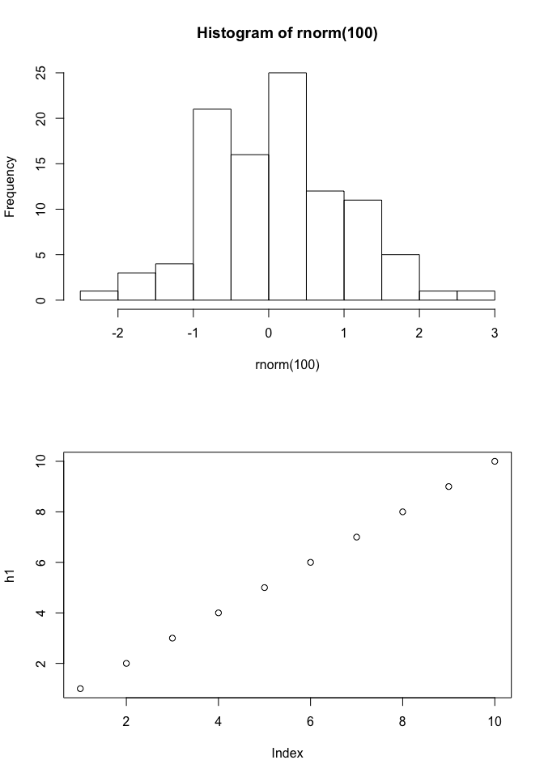

```r
# Lets set up some more "objects"
h1 <- 1:10        # Numbers 1-10

layout(matrix(seq(2)))
plot(h)
plot(h1)
```

```r
layout(1)
```

This capability demonstrates something called “method dispatch” where a top level function assess the class of an **S3** object and calls the appropriate sub-function.

```r
class(h)
```

```
## [1] "histogram"
```

```r
class(h1)
```

```
## [1] "integer"
```

```r
methods("plot")
```

```
##  [1] plot,ANY,ANY-method
##  [2] plot,Spatial,missing-method
##  [3] plot,SpatialCollections,missing-method
##  [4] plot,SpatialGrid,missing-method
##  [5] plot,SpatialGridDataFrame,missing-method
##  [6] plot,SpatialLines,missing-method
##  [7] plot,SpatialMultiPoints,missing-method
##  [8] plot,SpatialPixels,missing-method
##  [9] plot,SpatialPixelsDataFrame,missing-method
## [10] plot,SpatialPoints,missing-method
## [11] plot,SpatialPolygons,missing-method
## [12] plot,SpatialRings,missing-method
## [13] plot,gpc.poly,ANY-method
## [14] plot.HoltWinters*
## [15] plot.TukeyHSD*
```

[output cut: 30 more lines]

It turns out there are lots of “plot” functions. If you try to plot an object of class `histogram` you will end up calling `plot.histogram` whereas plotting an object of class `integer` ends up calling `plot.default`.

## S4 Objects

While **S3** objects are simple, they do no allow many of the fancier features associated with “Object Oriented Programming” (OOP). As R evolved, people came up with **S4** objects to address this. We won’t go into the details about what is possible but just point out how to use **S4** objects from the **sp** package.

- S4 objects have “slots”
- S4 slots are accessed using `@`

### What is an S4 Object

The **MazamaSpatialUtils** package uses **sp** and creates **S4** objects:

```r
# Load the 'SimpleCountries' dataset
library(MazamaSpatialUtils)
data("SimpleCountries")

class(SimpleCountries)
```

```
## [1] "SpatialPolygonsDataFrame"
## attr(,"package")
## [1] "sp"
```

```r
typeof(SimpleCountries)
```

```
## [1] "S4"
```

```r
# It's big so we don't just print out the attributes
a <- attributes(SimpleCountries)
class(a)
```

```
## [1] "list"
```

```r
names(a)
```

```
## [1] "data"        "polygons"    "plotOrder"   "bbox"        "proj4string"
## [6] "class"
```

### Accessing S4 components

```r
# S4 objects have 'slots'
slotNames(SimpleCountries)
```

```
## [1] "data"        "polygons"    "plotOrder"   "bbox"        "proj4string"
```

```r
# Access slots using 'slot()' or '@'
class(slot(SimpleCountries, "data"))
```

```
## [1] "data.frame"
```

```r
class(SimpleCountries@data)
```

```
## [1] "data.frame"
```

## SPDF Objects

Each `SpatialPolygonsDataFrame` is an **S4** object with a 1:1 relationship between records (rows) in the `@data` dataframe and `Polygons` **S4** objects in the `@polygons` list. This makes it possible to use *some* functions like `subset()` that work on dataframes. The following code shows how to work with them.

```r
# Compare 'data' and 'polygons' slots
nrow(SimpleCountries@data)
```

```
## [1] 246
```

```r
length(SimpleCountries@polygons)
```

```
## [1] 246
```

```r
# Look at the first record
str(SimpleCountries@data[1,])
```

```
## 'data.frame':    1 obs. of  6 variables:
##  $ countryCode: chr "AG"
##  $ countryName: chr "Antigua and Barbuda"
##  $ ISO3       : chr "ATG"
##  $ FIPS       : chr "AC"
##  $ UN_region  : int 19
##  $ polygonID  : chr "AG"
```

```r
# We can also use normal dataframe syntax to access columns of data
SimpleCountries$countryName[1]
```

```
## [1] "Antigua and Barbuda"
```

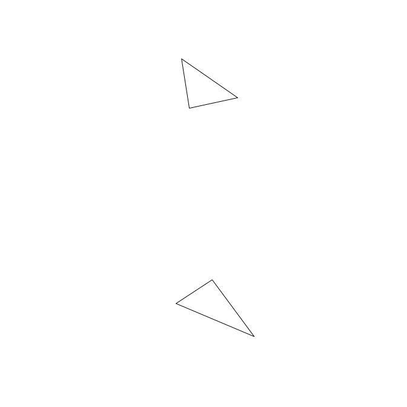

```r
# Magic happens when we plot using normal dataframe syntax
plot(SimpleCountries[1,])
```

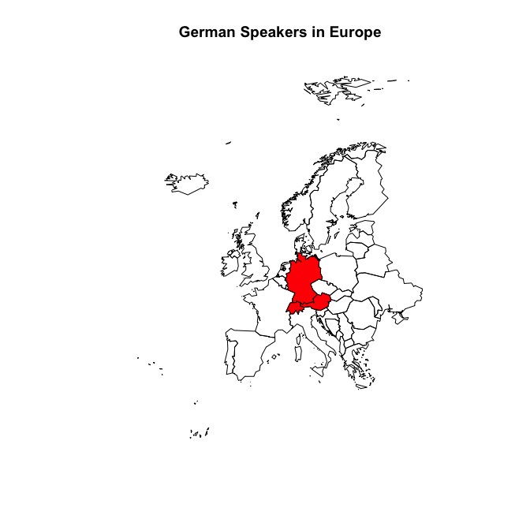

```r
# Here is a more advanced example using pipes
SimpleCountries %>%
  subset(UN_region == 150) %>%
  subset(countryCode != "RU") %>%
  plot()

SimpleCountries %>%
  subset(countryCode %in% c("DE", "AT", "CH")) %>%
  plot(col = 'red', add = TRUE)

title("German Speakers in Europe")
```

Best of luck making interesting maps!

*Mazama Science*